# 2022 Spring 2100 Final answers (33 points total)

jsg

Last compiled on 15 December, 2022 08:49

# Instructions! Read this first.

The exam is open note, open course website, open class-related code repositories (mine and those you produced in class). However, you may not get external help ( from other students, directed internet searches, etc.). Please update the statement below to acknowledge these instructions (and that you can use git).

Note some questions are based on pretend surveys, etc, for teaching purposes.

Good luck!

## Making the data for # 4 (not in student version)

Real data from:

- https://covid.cdc.gov/covid-data-tracker/#vaccinations_vacc-people-onedose-pop-5yr
- https://www2.census.gov/geo/pdfs/maps-data/maps/reference/us_regdiv.pdf

```r
regions <- read.csv("https://docs.google.com/spreadsheets/d/e/2PACX-1vSHjDv2eSCOtuux9E6JIoEx2F4cOyU6jX6mXUr_FQDtTjpQxroh-IP_3D1z_qcSDr-9lQRQG_CRMZXY/pub?gid=0&single=true&output=csv",
                    stringsAsFactors = T)
ratestotal <- read.csv("https://docs.google.com/spreadsheets/d/e/2PACX-1vTSY3PjqxOgUcMtx15Dzh1Z_TelhY6lsRloAyV65vKhqaPEahv5ojY_y7IOstTuUokyHtAYarkb6qqo/pub?gid=993160825&single=true&output=csv",
                   stringsAsFactors =T)
str(regions)
```

```
## 'data.frame':    51 obs. of  4 variables:
##  $ State     : Factor w/ 51 levels "Alabama","Alaska",..: 2 1 4 3 5 6 7 9 8 10 ...
##  $ State.Code: Factor w/ 51 levels "AK","AL","AR",..: 1 2 3 4 5 6 7 8 9 10 ...
##  $ Region    : Factor w/ 4 levels "Midwest","Northeast",..: 4 3 3 4 4 4 2 3 3 3 ...
##  $ Division  : Factor w/ 9 levels "East North Central",..: 6 2 9 4 6 4 5 7 7 7 ...
```

```r
str(ratestotal)
```

[output not shown]

[output cut: 68 more lines]

separate only some dates for rates

```r
rates_focal <- ratestotal[ratestotal$Date %in% c("03/22/2021","03/21/2022"),c("Date","Location","Admin_Per_100K")]
library(reshape2)
rates_wide <- dcast(rates_focal, Location ~ Date, value = "Admin_Per_100k" )
```

merge

```r
names(rates_wide)[names(rates_wide) == "Location"] = "State.Code"
covid_regions_wide <- merge(rates_wide, regions, all.x = F, all.y = T)
names(covid_regions_wide)[2:3] <- c("early", "late")
covid_regions_wide$change <- covid_regions_wide$late - covid_regions_wide$early
covid_regions_wide <- covid_regions_wide[,c("State", "early", "late","Region", "change")]
#covid_regions_wide_south <- covid_regions_wide[covid_regions_wide$Region %in% c("South"),]
#covid_regions_wide_ne <- covid_regions_wide[covid_regions_wide$Region %in% c("Northeast"),]
#write.csv(covid_regions_wide_south, "covid_regions_wide_south.csv", row.names = F)
write.csv(covid_regions_wide, "covid_regions_wide.csv", row.names = F)
```

## COVID impacts

### 1.

```r
covid_rates_over_year <- read.csv("https://docs.google.com/spreadsheets/d/e/2PACX-1vRLp3znA4ARXCNLlVHj4VSFPHyE7qCTHcs1xWDULfYxUux_6Fia_ugbVnHu8cURowahXWLz5yT7JFf1/pub?gid=1458185696&single=true&output=csv",
                                  stringsAsFactors = T)
```

Investigate the question. Make sure you include (6 pts)

- null hypothesis
  - *H<sub>0</sub>: Regions do not differ in rates of changes in vaccination*
- alternative hypothesis
  - *H<sub>A</sub>: Regions do differ in rates of changes in vaccination*
- explanation for test you will use
  - I will use an ANOVA (form of linear model) since we have a continous outcome variable and a categorical predictor with more than 2 levels (else it would be a t-test)
- results from statistical test

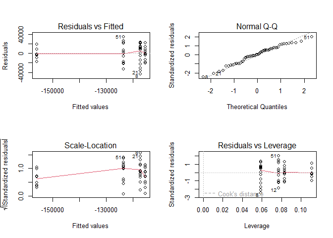

```r
vaccine_lm <- lm(change~Region, covid_rates_over_year)
par(mfrow=c(2,2))
plot(vaccine_lm)
```

```r
summary(vaccine_lm)
```

```
##
## Call:
## lm(formula = change ~ Region, data = covid_rates_over_year)
##
## Residuals:
##    Min     1Q Median     3Q    Max
## -43364 -13754    135  12714  34659
##
## Coefficients:
##                 Estimate Std. Error t value Pr(>|t|)
## (Intercept)      -115274       5277 -21.846  < 2e-16 ***
## RegionNortheast   -40778       8060  -5.059 6.89e-06 ***
## RegionSouth        -1935       6892  -0.281    0.780
## RegionWest         -8290       7318  -1.133    0.263
## ---
## Signif. codes:  0 '***' 0.001 '**' 0.01 '*' 0.05 '.' 0.1 ' ' 1
##
## Residual standard error: 18280 on 47 degrees of freedom
## Multiple R-squared:  0.409,  Adjusted R-squared:  0.3713
## F-statistic: 10.84 on 3 and 47 DF,  p-value: 1.566e-05
```

```r
library(car)
Anova(vaccine_lm, type="III")
```

```
## Anova Table (Type III tests)
##
## Response: change
##                 Sum Sq Df F value    Pr(>F)
## (Intercept) 1.5946e+11  1 477.235 < 2.2e-16 ***
## Region      1.0869e+10  3  10.843 1.566e-05 ***
## Residuals   1.5704e+10 47
## ---
## Signif. codes:  0 '***' 0.001 '**' 0.01 '*' 0.05 '.' 0.1 ' ' 1
```

```r
library(multcomp)
region_compare <-   glht(vaccine_lm, linfct = mcp(Region = "Tukey"))
summary(region_compare)
```

```
##
##   Simultaneous Tests for General Linear Hypotheses
##
## Multiple Comparisons of Means: Tukey Contrasts
##
##
## Fit: lm(formula = change ~ Region, data = covid_rates_over_year)
##
## Linear Hypotheses:
##                          Estimate Std. Error t value Pr(>|t|)
## Northeast - Midwest == 0   -40778       8060  -5.059  < 1e-04 ***
## South - Midwest == 0        -1935       6892  -0.281 0.992126
## West - Midwest == 0         -8290       7318  -1.133 0.670008
## South - Northeast == 0      38843       7535   5.155  < 1e-04 ***
## West - Northeast == 0       32488       7926   4.099 0.000922 ***
## West - South == 0           -6355       6735  -0.944 0.780587
## ---
## Signif. codes:  0 '***' 0.001 '**' 0.01 '*' 0.05 '.' 0.1 ' ' 1
## (Adjusted p values reported -- single-step method)
```

- clear explanation of how results relate to your stated hypotheses
  - Test assumptions appear to be met (no patterns in residuals, which are also normally distributed and homogeneous). ANOVA results indicate significant differences among regions (F<sub>3,47</sub>=10.843, p<.001), so I reject my null hypothesis. Given these results, I used a Tukey post hoc test to control FWER while also seeing how each region compares to others. Results indicate significant differences between the NE-MW, S-NE, and W-NE (so the NE differs from all other regions!).

### 2.

There has been concern that the COVID pandemic may differentially influence male and female fetuses and thus alter the regional sex ratios of newborn children (Abdoli 2020). When comparing biological males and females at birth, males have historically represented approximately 50% of births. A hospital in New York City recorded 55 male and 45 female births in 2021 (in the middle of the COVID pandemic). Use this data to investigate if sex ratios have changed.

Make sure you include (6 pts)

- null hypothesis
  - *H<sub>0</sub>: the sex ratio in 2021 is 50/50 (the historical average)*
- alternative hypothesis
  - *H<sub>A</sub>: the sex ratio in 2021 is not 50/50 (the historical average)*
- explanation for test you will use
  - *I will use a binomial test since we have 2 outcomes (male/female) and a historical proportion to compare to.
- results from statistical test

```r
binom.test(55,100)
```

```
##
##  Exact binomial test
##
## data:  55 and 100
## number of successes = 55, number of trials = 100, p-value = 0.3682
## alternative hypothesis: true probability of success is not equal to 0.5
## 95 percent confidence interval:
##  0.4472802 0.6496798
## sample estimates:
## probability of success
##                   0.55
```

- clear explanation of how results relate to your stated hypotheses
  - *Results indicate a p-value of .3682, so I fail to reject the null hypothesis. There is not evidence that COVID led to a change in sex ratios at birth.*

## To a happier place - Penguins!

3. 3 species of penguins (Gentoo, Chinstrap, Adelie) were measured for various morphological traits. Using the provided data, consider the impact of species(Species) and body mass (Body_mass_g) on flipper length (Flipper_length_mm). (6 pts)

```r
penguin <- read.csv("https://docs.google.com/spreadsheets/d/e/2PACX-1vQEyo_2bjGK6yEj5gj3SKP_VsqDxsqer4PRqTqqV_FRw9m0OM3u7SgbaT9OF4whgEb1Nx0z2QNU8ovd/pub?gid=836786692&single=true&output=csv", stringsAsFactors = T)
```

Make sure you include (6 pts)

- null hypothesis
- alternative hypothesis
- explanation for test you will use
- results from statistical test

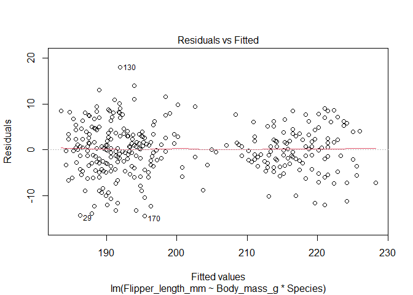

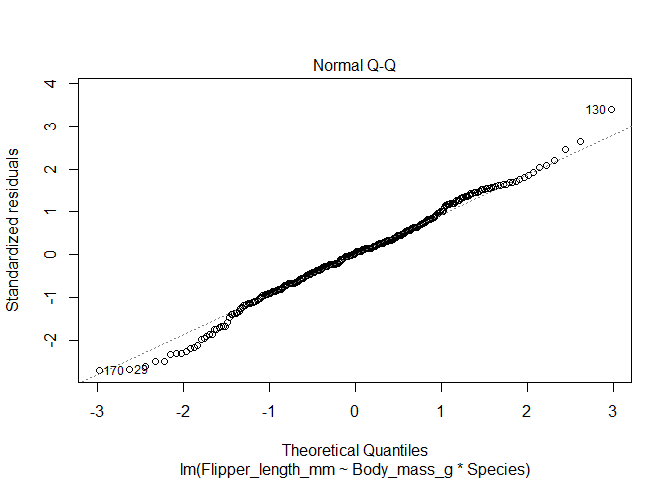

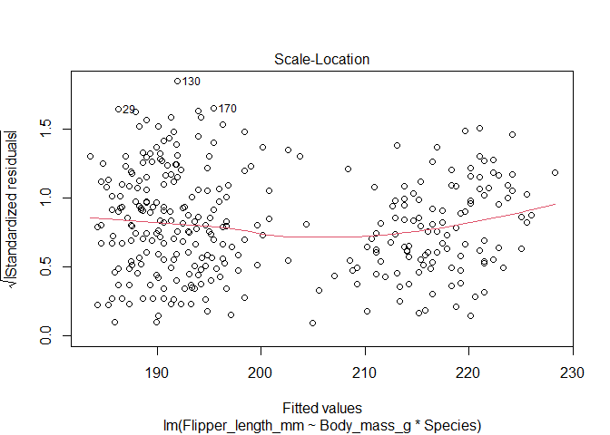

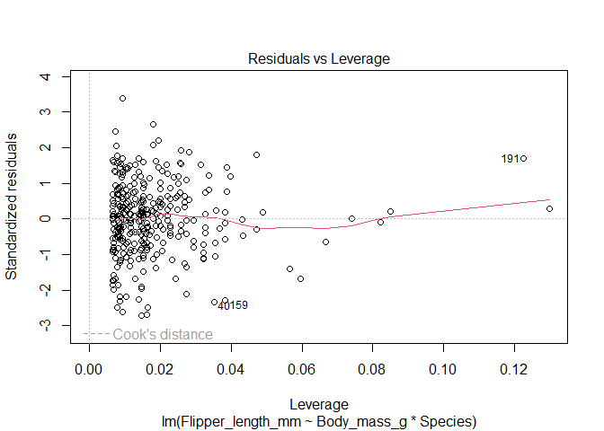

```r
penguin_lm_int <- lm(Flipper_length_mm~Body_mass_g*Species, penguin)
plot(penguin_lm_int)
```

```r
summary(penguin_lm_int)
```

```
##
## Call:
## lm(formula = Flipper_length_mm ~ Body_mass_g * Species, data = penguin)
##
## Residuals:
##      Min       1Q   Median       3Q      Max
## -14.4296  -3.3494   0.1719   3.3428  18.0477
##
## Coefficients:
##                                Estimate Std. Error t value Pr(>|t|)
## (Intercept)                   1.652e+02  3.551e+00  46.536  < 2e-16 ***
## Body_mass_g                   6.677e-03  9.523e-04   7.011  1.3e-11 ***
## SpeciesChinstrap             -1.386e+01  7.301e+00  -1.899  0.05844 .
## SpeciesGentoo                 6.059e+00  6.051e+00   1.001  0.31735
## Body_mass_g:SpeciesChinstrap  5.228e-03  1.949e-03   2.683  0.00766 **
## Body_mass_g:SpeciesGentoo     2.362e-03  1.353e-03   1.746  0.08164 .
## ---
## Signif. codes:  0 '***' 0.001 '**' 0.01 '*' 0.05 '.' 0.1 ' ' 1
##
## Residual standard error: 5.348 on 336 degrees of freedom
##   (2 observations deleted due to missingness)
## Multiple R-squared:  0.8575, Adjusted R-squared:  0.8553
## F-statistic: 404.2 on 5 and 336 DF,  p-value: < 2.2e-16
```

```r
Anova(penguin_lm_int, type = "III")
```

```
## Anova Table (Type III tests)
##
## Response: Flipper_length_mm
##                     Sum Sq  Df   F value    Pr(>F)
## (Intercept)          61947   1 2165.6129 < 2.2e-16 ***
## Body_mass_g           1406   1   49.1591 1.302e-11 ***
## Species                177   2    3.0994   0.04637 *
## Body_mass_g:Species    228   2    3.9837   0.01950 *
## Residuals             9611 336
## ---
## Signif. codes:  0 '***' 0.001 '**' 0.01 '*' 0.05 '.' 0.1 ' ' 1
```

interaction is significant, so complete for each

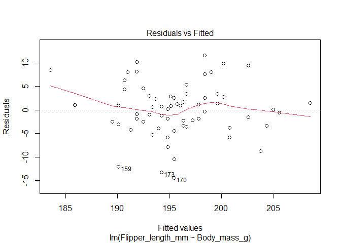

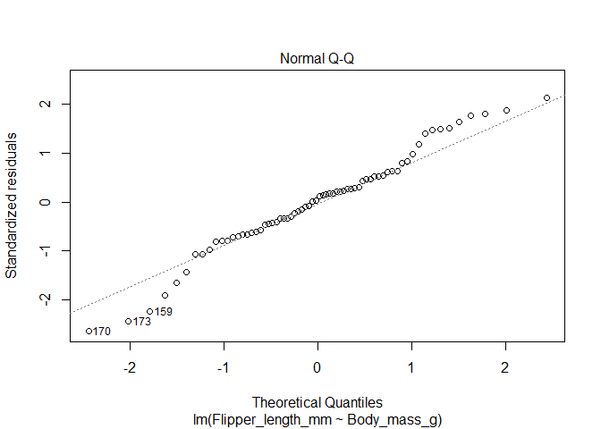

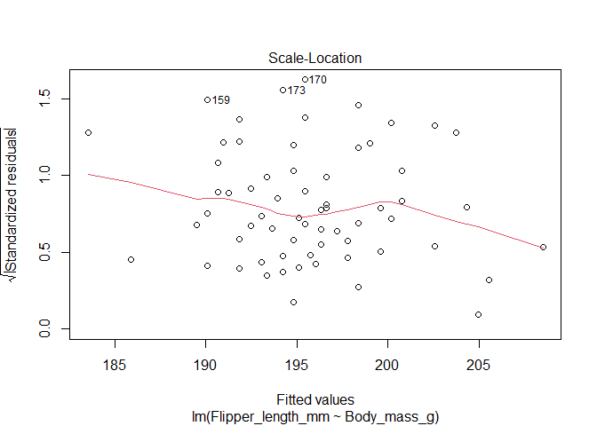

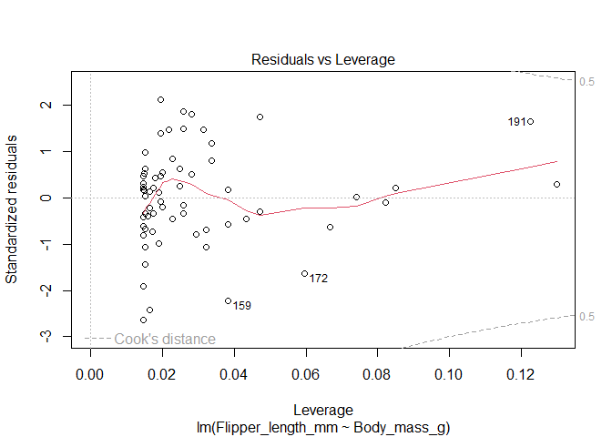

```r
chinstrap <- lm(Flipper_length_mm~Body_mass_g, penguin[penguin$Species == "Chinstrap",])
plot(chinstrap)
```

```r
summary(chinstrap)
```

```
##
## Call:
## lm(formula = Flipper_length_mm ~ Body_mass_g, data = penguin[penguin$Species ==
##     "Chinstrap", ])
##
## Residuals:
##      Min       1Q   Median       3Q      Max
## -14.4296  -3.3315   0.4097   2.8889  11.5941
##
## Coefficients:
##              Estimate Std. Error t value Pr(>|t|)
## (Intercept) 1.514e+02  6.575e+00  23.024  < 2e-16 ***
## Body_mass_g 1.191e-02  1.752e-03   6.795 3.75e-09 ***
## ---
## Signif. codes:  0 '***' 0.001 '**' 0.01 '*' 0.05 '.' 0.1 ' ' 1
##
## Residual standard error: 5.512 on 66 degrees of freedom
## Multiple R-squared:  0.4116, Adjusted R-squared:  0.4027
## F-statistic: 46.17 on 1 and 66 DF,  p-value: 3.748e-09
```

```r
Anova(chinstrap, type = "III")
```

```
## Anova Table (Type III tests)
##
## Response: Flipper_length_mm
##              Sum Sq Df F value    Pr(>F)
## (Intercept) 16106.0  1 530.120 < 2.2e-16 ***
## Body_mass_g  1402.7  1  46.168 3.748e-09 ***
## Residuals    2005.2 66
## ---
## Signif. codes:  0 '***' 0.001 '**' 0.01 '*' 0.05 '.' 0.1 ' ' 1
```

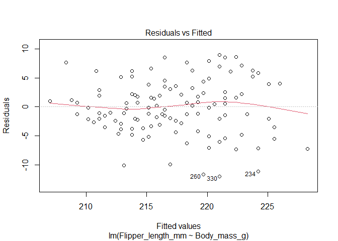

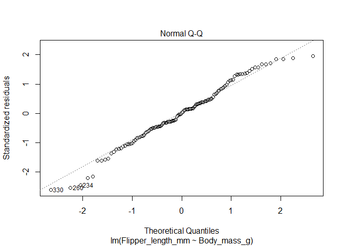

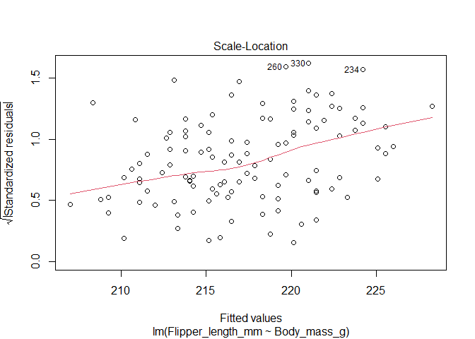

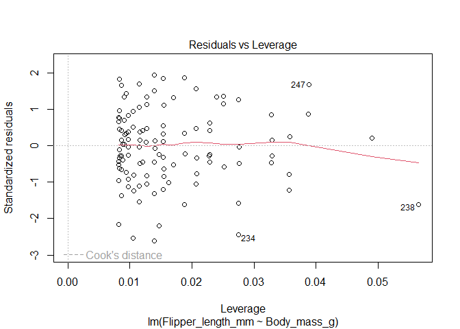

```r
Gentoo <- lm(Flipper_length_mm~Body_mass_g, penguin[penguin$Species == "Gentoo",])
plot(Gentoo)
```

```r
summary(Gentoo)
```

```
##
## Call:
## lm(formula = Flipper_length_mm ~ Body_mass_g, data = penguin[penguin$Species ==
##     "Gentoo", ])
##
## Residuals:
##      Min       1Q   Median       3Q      Max
## -12.0194  -2.7401   0.1781   2.9859   8.9806
##
## Coefficients:
##              Estimate Std. Error t value Pr(>|t|)
## (Intercept) 1.713e+02  4.244e+00   40.36   <2e-16 ***
## Body_mass_g 9.039e-03  8.321e-04   10.86   <2e-16 ***
## ---
## Signif. codes:  0 '***' 0.001 '**' 0.01 '*' 0.05 '.' 0.1 ' ' 1
##
## Residual standard error: 4.633 on 121 degrees of freedom
##   (1 observation deleted due to missingness)
## Multiple R-squared:  0.4937, Adjusted R-squared:  0.4896
## F-statistic:   118 on 1 and 121 DF,  p-value: < 2.2e-16
```

```r
Anova(Gentoo, type = "III")
```

```
## Anova Table (Type III tests)
##
## Response: Flipper_length_mm
##             Sum Sq  Df F value    Pr(>F)
## (Intercept)  34969   1 1628.99 < 2.2e-16 ***
## Body_mass_g   2533   1  118.01 < 2.2e-16 ***
## Residuals     2597 121
## ---
## Signif. codes:  0 '***' 0.001 '**' 0.01 '*' 0.05 '.' 0.1 ' ' 1
```